# Harmonizing the Domain 1 Marine Protected Area: new/updated krill and predators data to redefine boundaries and integrate seasonality in the MPA design

Lucas Krüger

2024-05-14

```r
knitr::opts_chunk$set(echo = TRUE)
```

## R Markdown

This code uses the previous layers used as conservation objectives in the development of the design of the Domain 1 Marine Protected Area (D1MPA) and adds new data available from openly available peer-reviewed literature to redefine the boundaries of General Protection Zones and use seasonality of predator distribution to introduce temporal variability in the proposition of the MPA.

The code follows up from the previously standardized tracking data and standardized 2018 layers, files 01_Raw_Tracking_Data_Processment.R and 02_Krill_and_Predator_Layers_2018_rasterization.R

First, use the ‘trip’ package to regularize tracking data and calcualte cumulative area usage in 3-months periods (JFM, AMJ,JAS and OND)

```r
library(lubridate)
library(raster)
library(dplyr)
library(adehabitatHR)
library(adehabitatLT)
library(sp)
library(trip)
```

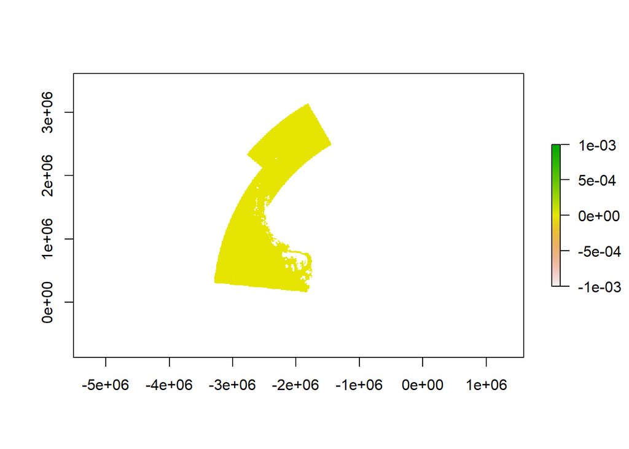

```r
library(ggplot2)
library(patchwork)
library(terra)
library(reshape2)
mask <- raster("C:/D1MPA_2024_Harmony/D1MPA_Harmonized/D1_Mask/D1_Mask.tif") # mask

plot(mask)
```

```r
EPSG6932<-crs(mask) # extract the coordinate spatial system from the object

EPSG4326<-CRS("+proj=longlat +datum=WGS84 +no_defs")

D1<-shapefile("C:/D1MPA_2024_Harmony/D1MPA_Harmonized/Shapefiles/D1_6932.shp")


###----------Humpback Whale----------

hbw.ld2<-read.csv("C:/D1MPA_2024_Harmony/D1MPA_Harmonized/Processed_Tracking_Data/Whale_Humpback.csv")

hbw.ld2$quarter<-quarter(hbw.ld2$date)

hbw.ld2$idy<-paste(hbw.ld2$id,year(hbw.ld2$date),month(hbw.ld2$date),week(hbw.ld2$date))

hbw.q1<-subset(hbw.ld2,quarter=="1")
hbw.q2<-subset(hbw.ld2,quarter=="2")


# JFM
d <- data.frame(x=hbw.q1$x,y=hbw.q1$y, tms=hbw.q1$date, id=hbw.q1$idy)
tr <- trip(d)
tg <- rasterize(tr, mask, field = "tms") # in seconds

y<-cover(tg,mask)/(3600)/24

max(y)
```

```
## class      : RasterLayer
## dimensions : 448, 377, 168896  (nrow, ncol, ncell)
## resolution : 10000, 10000  (x, y)
## extent     : -3844389, -74389.02, -867299.4, 3612701  (xmin, xmax, ymin, ymax)
## crs        : +proj=laea +lat_0=-90 +lon_0=0 +x_0=0 +y_0=0 +datum=WGS84 +units=m +no_defs
## source     : memory
## names      : layer
## values     : 0, 37.00043  (min, max)
```

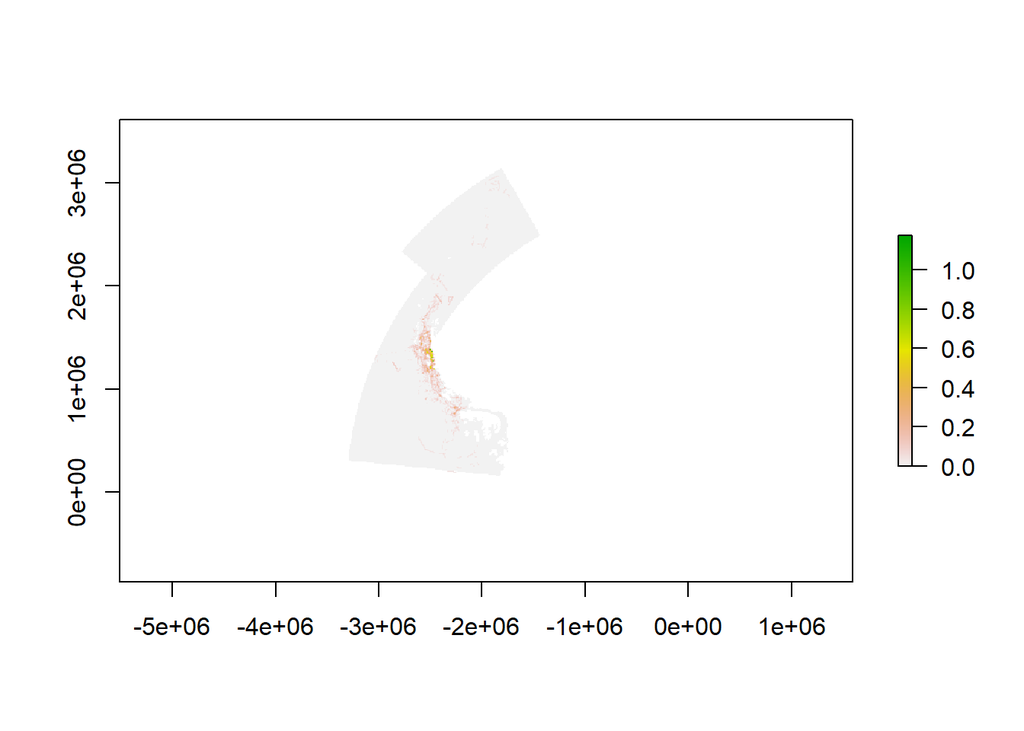

```r
ym<-y/31.45

plot(ym)
```

```r
writeRaster(ym,"C:/D1MPA_2024_Harmony/D1MPA_Harmonized/Predators_rescaled_area_usage/Whale_Humpback_JFM.tif", overwrite=TRUE)


# AMJ

d <- data.frame(x=hbw.q2$x,y=hbw.q2$y, tms=hbw.q2$date, id=hbw.q2$idy)
tr <- trip(d)
tg <- rasterize(tr, mask, field = "tms") # in seconds

y<-cover(tg,mask)/(3600)/24

max(y)
```

```
## class      : RasterLayer
## dimensions : 448, 377, 168896  (nrow, ncol, ncell)
## resolution : 10000, 10000  (x, y)
## extent     : -3844389, -74389.02, -867299.4, 3612701  (xmin, xmax, ymin, ymax)
## crs        : +proj=laea +lat_0=-90 +lon_0=0 +x_0=0 +y_0=0 +datum=WGS84 +units=m +no_defs
## source     : memory
## names      : layer
## values     : 0, 40.00277  (min, max)
```

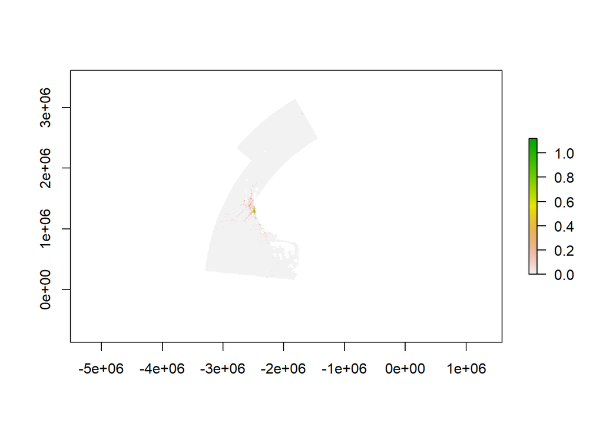

```r
ym<-y/35.7

plot(ym)
```

```r
writeRaster(ym,"C:/D1MPA_2024_Harmony/D1MPA_Harmonized/Predators_rescaled_area_usage/Whale_Humpback_AMJ.tif", overwrite=TRUE)

###----------Minke WHale--------------
amw.ld2<-read.csv("C:/D1MPA_2024_Harmony/D1MPA_Harmonized/Processed_Tracking_Data/Whale_AntarcticMinke.csv")

amw.q1<-subset(amw.ld2,quarter=="1")
amw.q2<-subset(amw.ld2,quarter=="2")


# JFM
d <- data.frame(x=amw.q1$x,y=amw.q1$y, tms=amw.q1$date, id=amw.q1$idy)
tr <- trip(d)
tg <- rasterize(tr, mask, field = "tms") # in seconds

y<-cover(tg,mask)/(3600)/24

max(y)
```

```
## class      : RasterLayer
## dimensions : 448, 377, 168896  (nrow, ncol, ncell)
## resolution : 10000, 10000  (x, y)
## extent     : -3844389, -74389.02, -867299.4, 3612701  (xmin, xmax, ymin, ymax)
## crs        : +proj=laea +lat_0=-90 +lon_0=0 +x_0=0 +y_0=0 +datum=WGS84 +units=m +no_defs
## source     : memory
## names      : layer
## values     : 0, 0.4885368  (min, max)
```

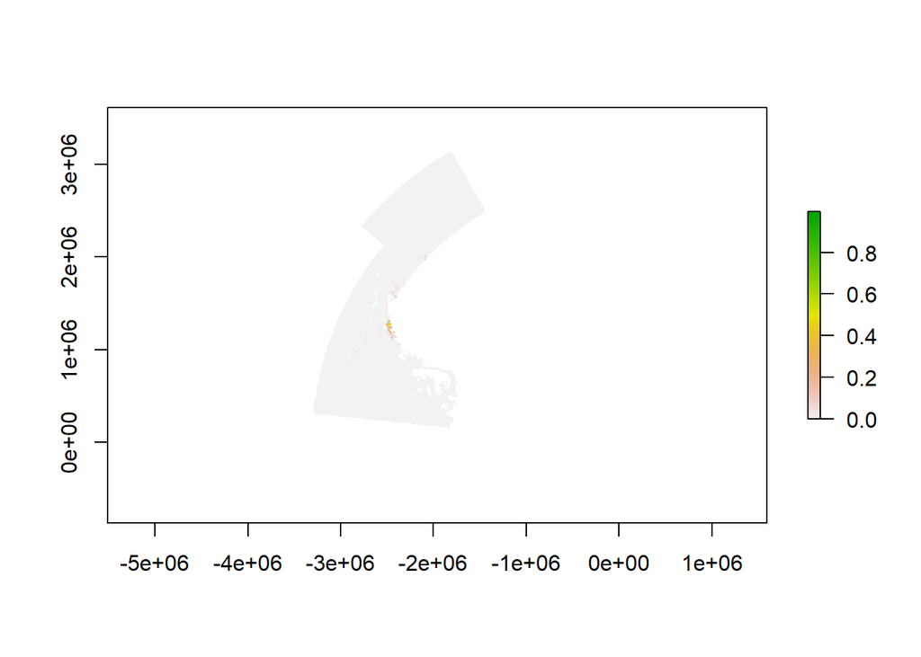

```r
ym<-y/0.49

plot(ym)
```

```r
writeRaster(ym,"C:/D1MPA_2024_Harmony/D1MPA_Harmonized/Predators_rescaled_area_usage/Whale_AntMinke_JFM.tif", overwrite=TRUE)


# AMJ

d <- data.frame(x=amw.q2$x,y=amw.q2$y, tms=amw.q2$date, id=amw.q2$idy)
tr <- trip(d)
tg <- rasterize(tr, mask, field = "tms") # in seconds

y<-cover(tg,mask)/(3600)/24

max(y)
```

```
## class      : RasterLayer
## dimensions : 448, 377, 168896  (nrow, ncol, ncell)
## resolution : 10000, 10000  (x, y)
## extent     : -3844389, -74389.02, -867299.4, 3612701  (xmin, xmax, ymin, ymax)
## crs        : +proj=laea +lat_0=-90 +lon_0=0 +x_0=0 +y_0=0 +datum=WGS84 +units=m +no_defs
## source     : memory
## names      : layer
## values     : 0, 0.1951229  (min, max)
```

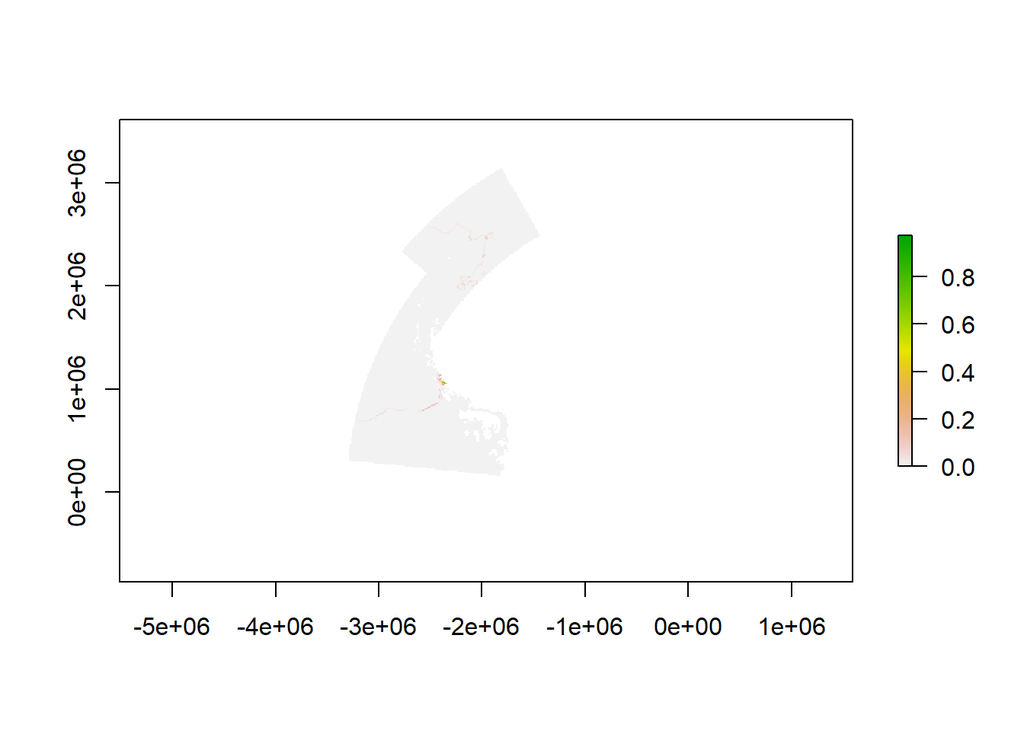

```r
ym<-y/0.20

plot(ym)
```

```r
writeRaster(ym,"C:/D1MPA_2024_Harmony/D1MPA_Harmonized/Predators_rescaled_area_usage/Whale_AntMinke_AMJ.tif", overwrite=TRUE)


#### -------------Crabeater Seal-----------------
crab.ld2<-read.csv("C:/D1MPA_2024_Harmony/D1MPA_Harmonized/Processed_Tracking_Data/Seal_Crabeater.csv")

crab.q1<-subset(crab.ld2,quarter=="1")
crab.q2<-subset(crab.ld2,quarter=="2")
crab.q3<-subset(crab.ld2,quarter=="3")
crab.q4<-subset(crab.ld2,quarter=="4")


# amj

d <- data.frame(x=crab.q2$x,y=crab.q2$y, tms=crab.q2$date, id=crab.q2$id)
tr <- trip(d)

tg <- rasterize(tr, mask, field = "tms") # in seconds

y<-cover(tg,mask)/(3600)/24

max(y)
```

```
## class      : RasterLayer
## dimensions : 448, 377, 168896  (nrow, ncol, ncell)
## resolution : 10000, 10000  (x, y)
## extent     : -3844389, -74389.02, -867299.4, 3612701  (xmin, xmax, ymin, ymax)
## crs        : +proj=laea +lat_0=-90 +lon_0=0 +x_0=0 +y_0=0 +datum=WGS84 +units=m +no_defs
## source     : memory
## names      : layer
## values     : 0, 71.22036  (min, max)
```

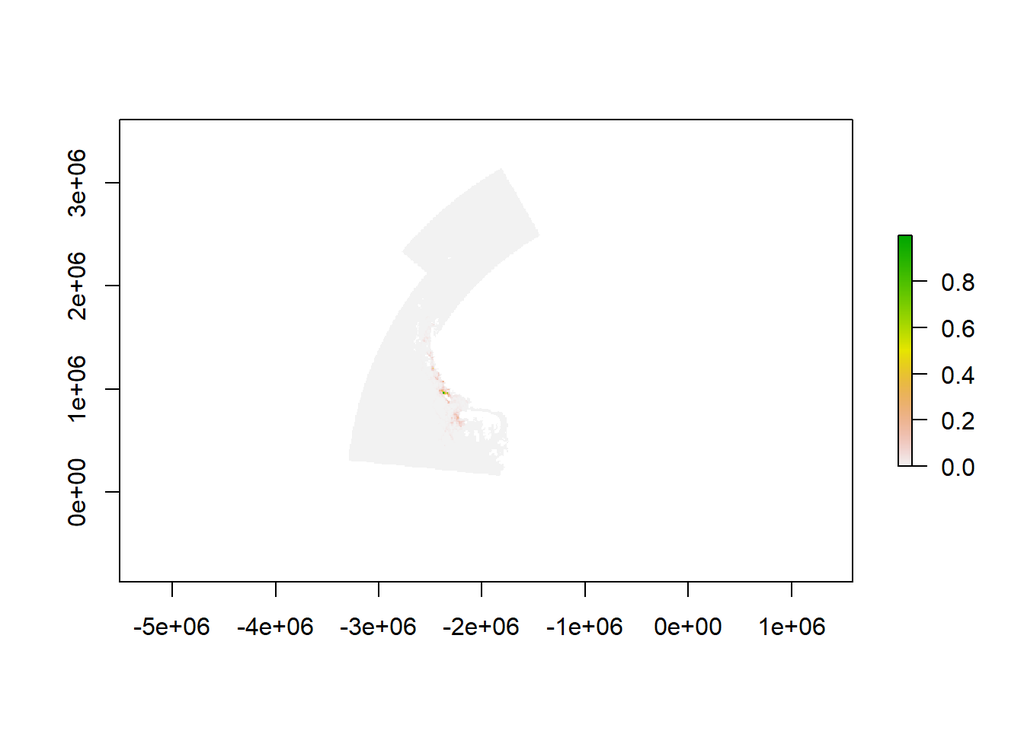

```r
ym<-y/71.221

plot(ym)
```

```r
writeRaster(ym,"C:/D1MPA_2024_Harmony/D1MPA_Harmonized/Predators_rescaled_area_usage/Seal_Crabeater_AMJ.tif", overwrite=TRUE)


# jas


d <- data.frame(x=crab.q3$x,y=crab.q3$y, tms=crab.q3$date, id=crab.q3$idy)
tr <- trip(d)
tg <- rasterize(tr, mask, field = "tms") # in seconds

y<-cover(tg,mask)/(3600)/24

max(y)
```

```
## class      : RasterLayer
## dimensions : 448, 377, 168896  (nrow, ncol, ncell)
## resolution : 10000, 10000  (x, y)
## extent     : -3844389, -74389.02, -867299.4, 3612701  (xmin, xmax, ymin, ymax)
## crs        : +proj=laea +lat_0=-90 +lon_0=0 +x_0=0 +y_0=0 +datum=WGS84 +units=m +no_defs
## source     : memory
## names      : layer
## values     : 0, 77.41393  (min, max)
```

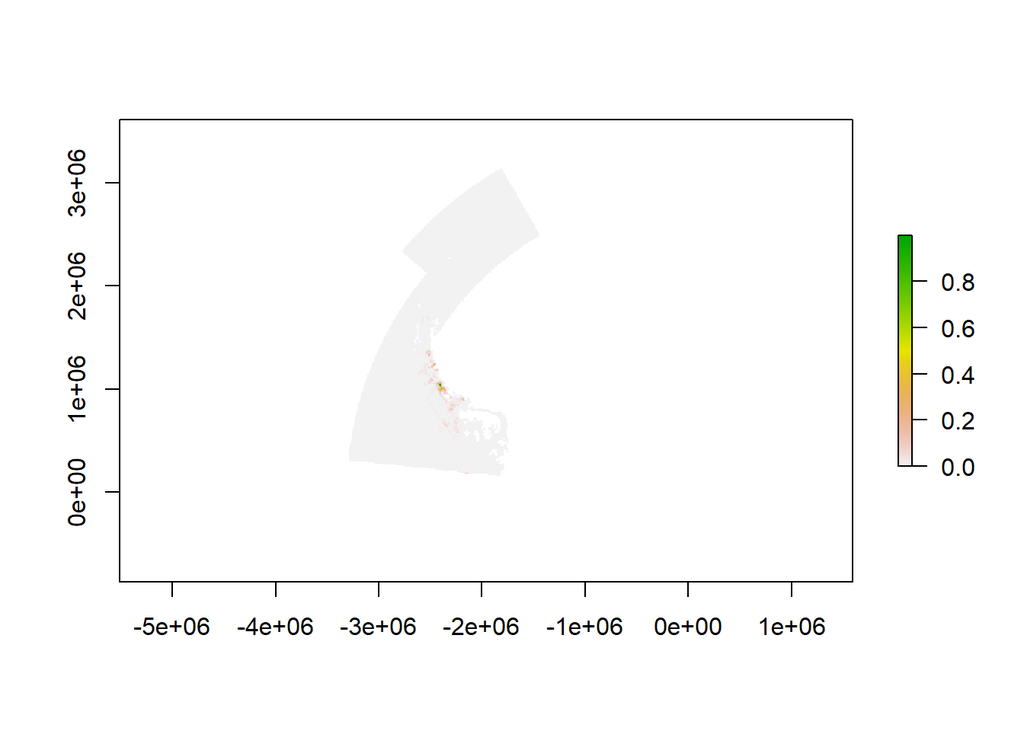

```r
ym<-y/77.44

plot(ym)
```

```r
writeRaster(ym,"C:/D1MPA_2024_Harmony/D1MPA_Harmonized/Predators_rescaled_area_usage/Seal_Crabeater_JAS.tif", overwrite=TRUE)

#ond

d <- data.frame(x=crab.q4$x,y=crab.q4$y, tms=crab.q4$date, id=crab.q4$idy)
tr <- trip(d)
tg <- rasterize(tr, mask, field = "tms") # in seconds

y<-cover(tg,mask)/(3600)/24

max(y)
```

```
## class      : RasterLayer
## dimensions : 448, 377, 168896  (nrow, ncol, ncell)
## resolution : 10000, 10000  (x, y)
## extent     : -3844389, -74389.02, -867299.4, 3612701  (xmin, xmax, ymin, ymax)
## crs        : +proj=laea +lat_0=-90 +lon_0=0 +x_0=0 +y_0=0 +datum=WGS84 +units=m +no_defs
## source     : memory
## names      : layer
## values     : 0, 31.10854  (min, max)
```

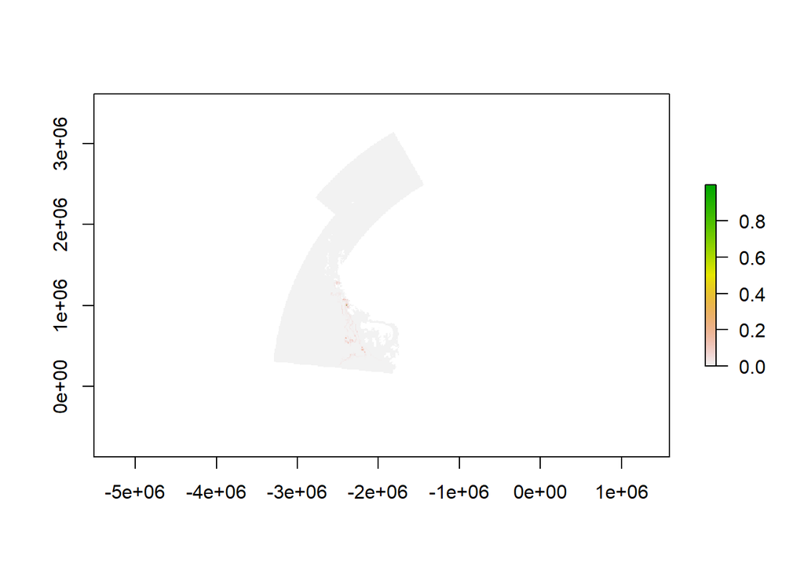

```r
ym<-y/31.11

plot(ym)
```

```r
writeRaster(ym,"C:/D1MPA_2024_Harmony/D1MPA_Harmonized/Predators_rescaled_area_usage/Seal_Crabeater_OND.tif", overwrite=TRUE)


###------Antarctic Fur Seal----------------

afs.ld2<-read.csv("C:/D1MPA_2024_Harmony/D1MPA_Harmonized/Processed_Tracking_Data/Seal_Fur.csv")

afs.ld2$quarter<-quarter(afs.ld2$date)
afs.q1<-subset(afs.ld2,quarter=="1")
afs.q2<-na.omit(subset(afs.ld2,quarter=="2"))
afs.q3<-subset(afs.ld2,quarter=="3")
afs.q4<-subset(afs.ld2,quarter=="4")

#jfm

d <- data.frame(x=afs.q1$x,y=afs.q1$y, tms=afs.q1$date, id=afs.q1$IDy)
tr <- trip(d)
tg <- rasterize(tr, mask, field = "tms") # in seconds

y<-cover(tg,mask)/(3600)/24

max(y)
```

```
## class      : RasterLayer
## dimensions : 448, 377, 168896  (nrow, ncol, ncell)
## resolution : 10000, 10000  (x, y)
## extent     : -3844389, -74389.02, -867299.4, 3612701  (xmin, xmax, ymin, ymax)
## crs        : +proj=laea +lat_0=-90 +lon_0=0 +x_0=0 +y_0=0 +datum=WGS84 +units=m +no_defs
## source     : memory
## names      : layer
## values     : 0, 592.9797  (min, max)
```

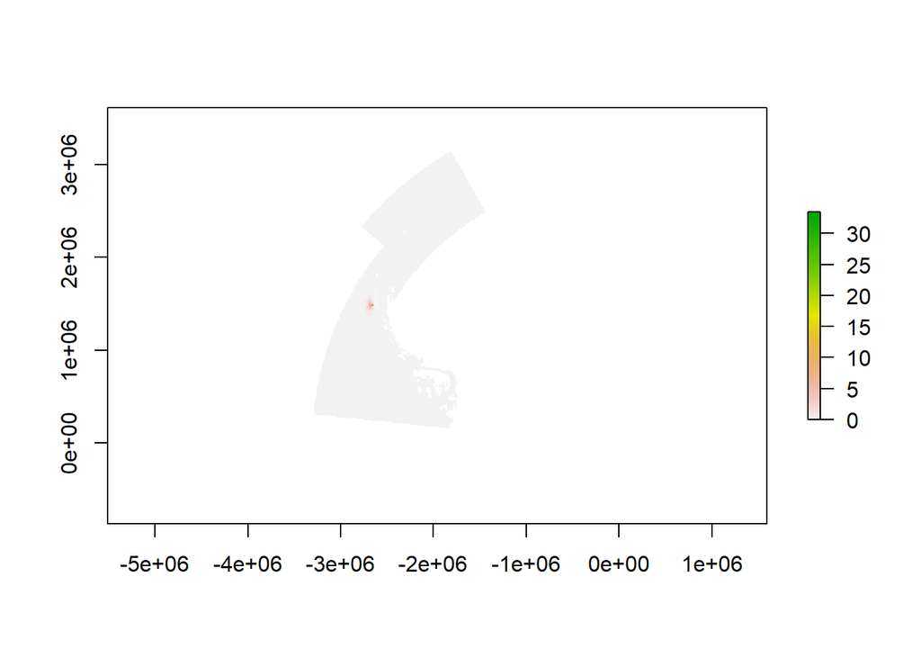

```r
ym<-y/17.7

plot(ym)
```

```r
writeRaster(ym,"C:/D1MPA_2024_Harmony/D1MPA_Harmonized/Predators_rescaled_area_usage/Seal_Fur_JFM.tif", overwrite=TRUE)

# amj

d <- data.frame(x=afs.q2$x,y=afs.q2$y, tms=afs.q2$date, id=afs.q2$IDy)
tr <- trip(d,correct_all = T)
tg <- rasterize(tr, mask, field = "tms") # in seconds

y<-cover(tg,mask)/(3600)/24
y<-y+mask
max(y)
```

```
## class      : RasterLayer
## dimensions : 448, 377, 168896  (nrow, ncol, ncell)
## resolution : 10000, 10000  (x, y)
## extent     : -3844389, -74389.02, -867299.4, 3612701  (xmin, xmax, ymin, ymax)
## crs        : +proj=laea +lat_0=-90 +lon_0=0 +x_0=0 +y_0=0 +datum=WGS84 +units=m +no_defs
## source     : memory
## names      : layer
## values     : 0, 209.9985  (min, max)
```

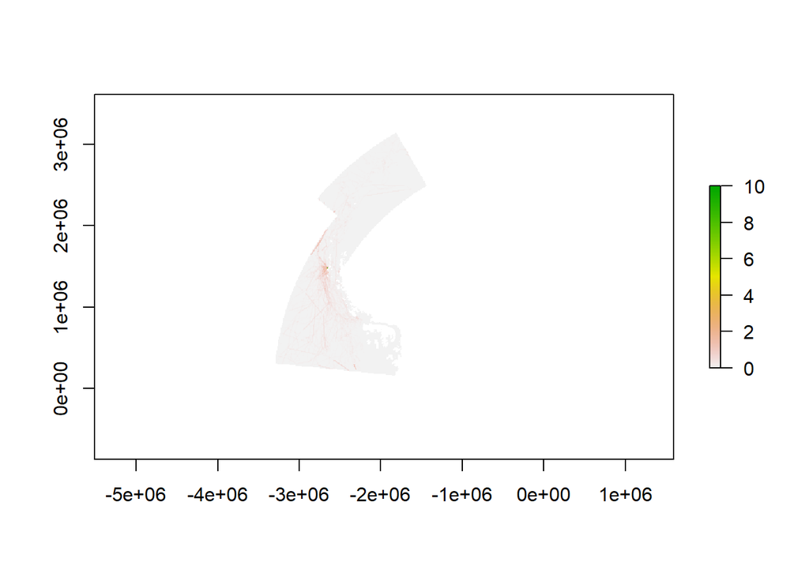

```r
ym<-y/20.94

plot(ym)
```

```r
writeRaster(ym,"C:/D1MPA_2024_Harmony/D1MPA_Harmonized/Predators_rescaled_area_usage/Seal_Fur_AMJ.tif", overwrite=TRUE)


# jas
afs.q3$IDy<-paste(afs.q3$id,year(afs.q3$date),week(afs.q3$date))
d <- data.frame(x=afs.q3$x,y=afs.q3$y, tms=afs.q3$date, id=afs.q3$IDy)
tr <- trip(d)
tg <- rasterize(tr, mask, field = "tms") # in seconds

y<-cover(tg,mask)/(3600)/24
y<-y+mask
max(y)
```

```
## class      : RasterLayer
## dimensions : 448, 377, 168896  (nrow, ncol, ncell)
## resolution : 10000, 10000  (x, y)
## extent     : -3844389, -74389.02, -867299.4, 3612701  (xmin, xmax, ymin, ymax)
## crs        : +proj=laea +lat_0=-90 +lon_0=0 +x_0=0 +y_0=0 +datum=WGS84 +units=m +no_defs
## source     : memory
## names      : layer
## values     : 0, 7.237384  (min, max)
```

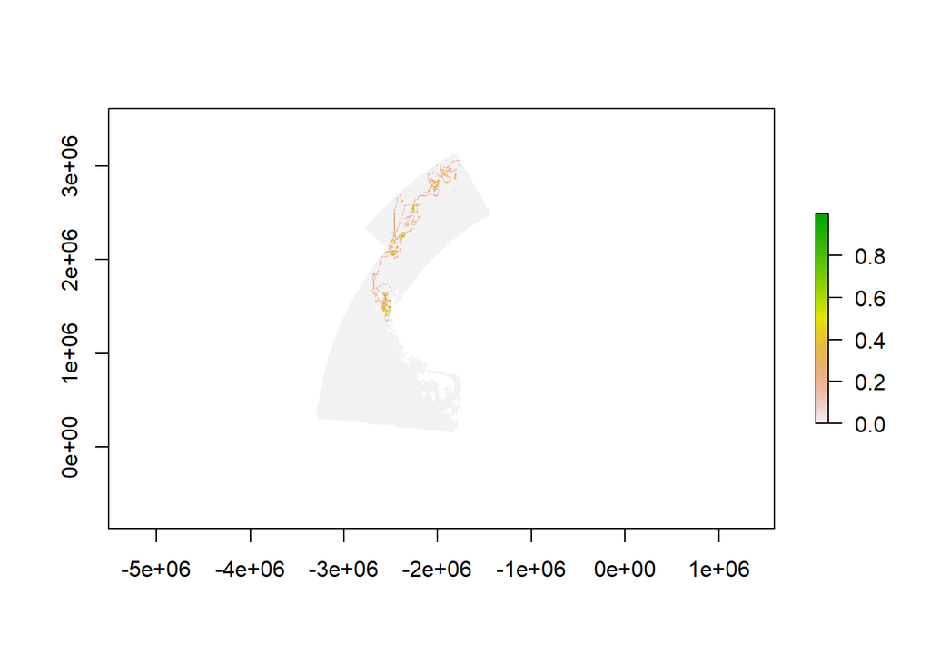

```r
ym<-y/7.24

plot(ym)
```

```r
writeRaster(ym,"C:/D1MPA_2024_Harmony/D1MPA_Harmonized/Predators_rescaled_area_usage/Seal_Fur_JAS.tif", overwrite=TRUE)

#ond

afs.q4$IDy<-paste(afs.q4$id,year(afs.q4$date),week(afs.q4$date))
d <- data.frame(x=afs.q4$x,y=afs.q4$y, tms=afs.q4$date, id=afs.q4$IDy)
tr <- trip(d)
tg <- rasterize(tr, mask, field = "tms") # in seconds

y<-(cover(tg,mask)/(3600)/24)+mask

max(y)
```

```
## class      : RasterLayer
## dimensions : 448, 377, 168896  (nrow, ncol, ncell)
## resolution : 10000, 10000  (x, y)
## extent     : -3844389, -74389.02, -867299.4, 3612701  (xmin, xmax, ymin, ymax)
## crs        : +proj=laea +lat_0=-90 +lon_0=0 +x_0=0 +y_0=0 +datum=WGS84 +units=m +no_defs
## source     : memory
## names      : layer
## values     : 0, 99.99354  (min, max)
```

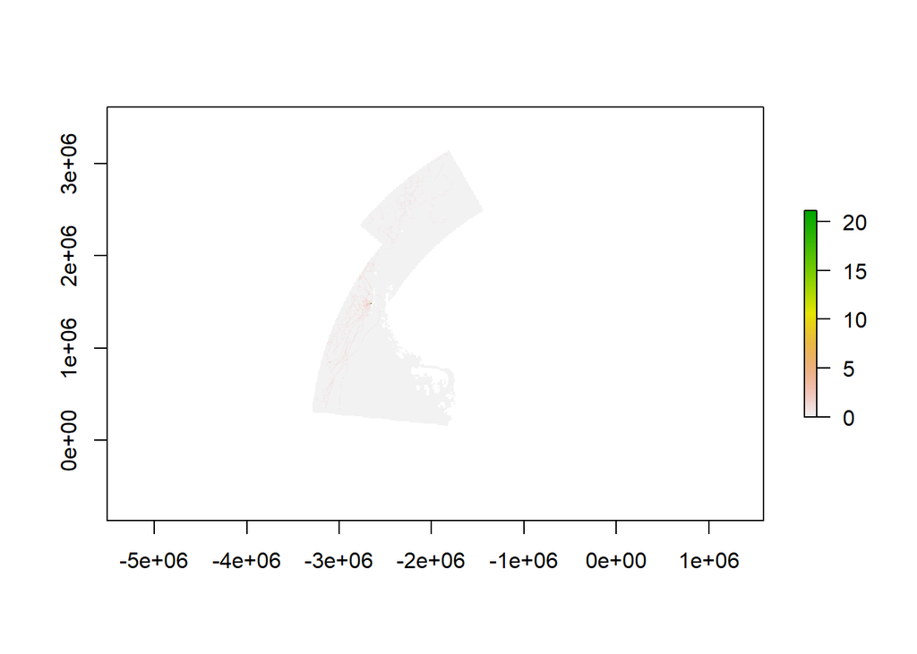

```r
ym<-y/4.73

plot(ym)
```

```r
writeRaster(y,"C:/D1MPA trimestral/Trip/Seal_Fur_OND.tif", overwrite=TRUE)


###-----------Elephant Seal----------------

soes.ld2<-read.csv("C:/D1MPA_2024_Harmony/D1MPA_Harmonized/Processed_Tracking_Data/Seal_Elephant.csv")

soes.ld2$quarter<-quarter(soes.ld2$date)
summary(as.factor(soes.ld2$quarter))
```

```
##     1     2     3     4
## 59314 57432 43541 28433
```

```r
soes.q1<-subset(soes.ld2,quarter=="1")
soes.q2<-subset(soes.ld2,quarter=="2")
soes.q3<-subset(soes.ld2,quarter=="3")
soes.q4<-subset(soes.ld2,quarter=="4")


#jfm

d <- data.frame(x=soes.q1$x,y=soes.q1$y, tms=soes.q1$date, id=soes.q1$idy)
tr <- trip(d)
tg <- rasterize(tr, mask, field = "tms") # in seconds

y<-(cover(tg,mask)/(3600)/24)+mask

max(y)
```

```
## class      : RasterLayer
## dimensions : 448, 377, 168896  (nrow, ncol, ncell)
## resolution : 10000, 10000  (x, y)
## extent     : -3844389, -74389.02, -867299.4, 3612701  (xmin, xmax, ymin, ymax)
## crs        : +proj=laea +lat_0=-90 +lon_0=0 +x_0=0 +y_0=0 +datum=WGS84 +units=m +no_defs
## source     : memory
## names      : layer
## values     : 0, 410.0035  (min, max)
```

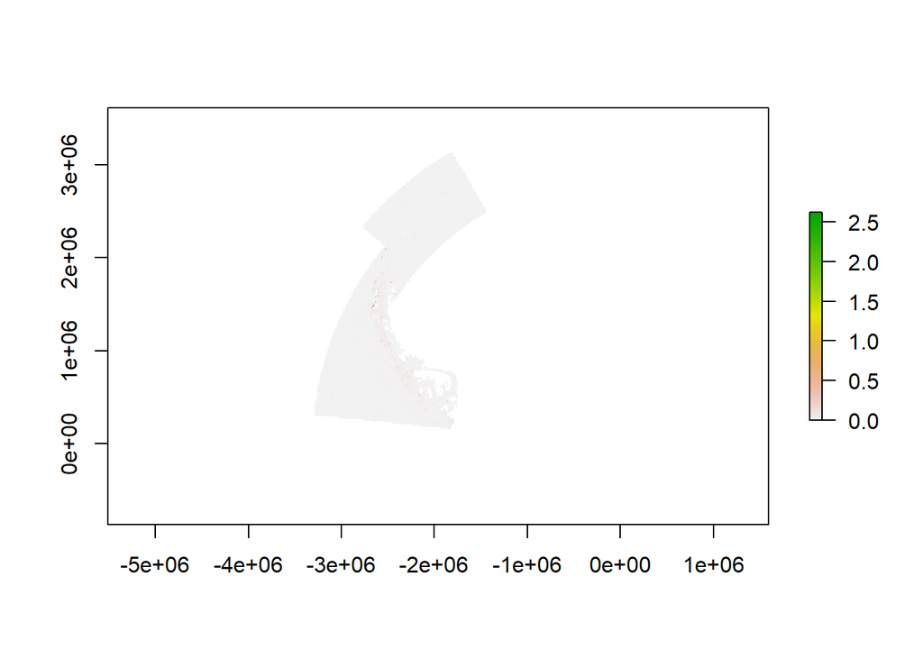

```r
ym<-y/156.1

plot(ym)
```

```r
writeRaster(ym,"C:/D1MPA_2024_Harmony/D1MPA_Harmonized/Predators_rescaled_area_usage/Seal_Elephant_JFM.tif", overwrite=TRUE)

# amj

dq2 <- data.frame(x=soes.q2$x,y=soes.q2$y, tms=soes.q2$date, id=soes.q2$idy)
tr2 <- trip(dq2,correct_all = T)
tg2 <- rasterize(tr2, mask, field = "tms") # in seconds

y2<-(cover(tg2,mask)/(3600)/24)+mask

max(y2)
```

```
## class      : RasterLayer
## dimensions : 448, 377, 168896  (nrow, ncol, ncell)
## resolution : 10000, 10000  (x, y)
## extent     : -3844389, -74389.02, -867299.4, 3612701  (xmin, xmax, ymin, ymax)
## crs        : +proj=laea +lat_0=-90 +lon_0=0 +x_0=0 +y_0=0 +datum=WGS84 +units=m +no_defs
## source     : memory
## names      : layer
## values     : 0, 108.0017  (min, max)
```

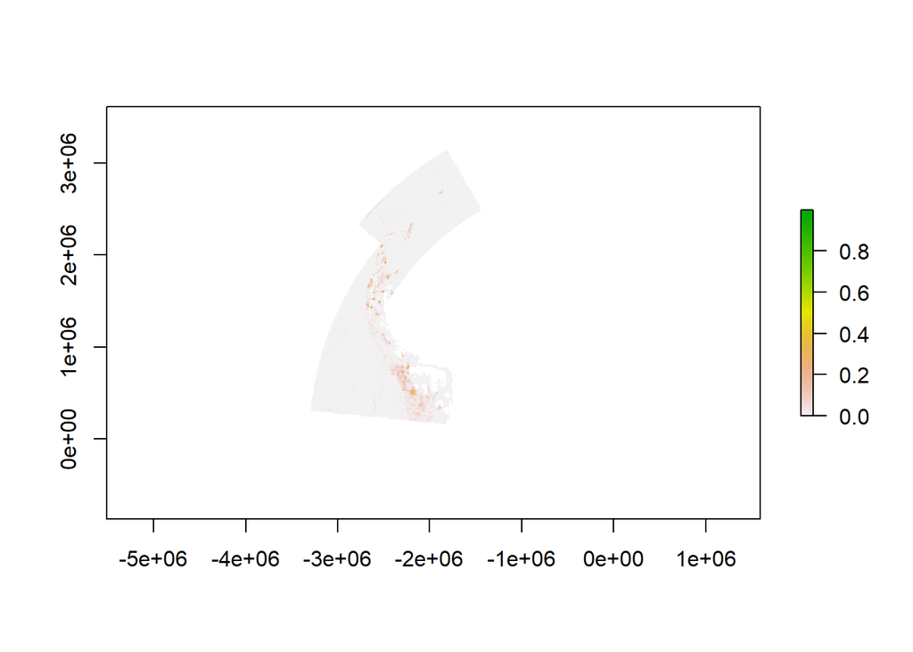

```r
ym2<-y2/108.01

plot(ym2)
```

```r
writeRaster(ym2,"C:/D1MPA_2024_Harmony/D1MPA_Harmonized/Predators_rescaled_area_usage/Seal_Elephant_AMJ.tif", overwrite=TRUE)

# jas

d3 <- data.frame(x=soes.q3$x,y=soes.q3$y, tms=soes.q3$date, id=soes.q3$idy)
tr3 <- trip(d3)
tg3 <- rasterize(tr3, mask, field = "tms") # in seconds

y3<-(cover(tg3,mask)/(3600)/24)+mask

max(y3)
```

```
## class      : RasterLayer
## dimensions : 448, 377, 168896  (nrow, ncol, ncell)
## resolution : 10000, 10000  (x, y)
## extent     : -3844389, -74389.02, -867299.4, 3612701  (xmin, xmax, ymin, ymax)
## crs        : +proj=laea +lat_0=-90 +lon_0=0 +x_0=0 +y_0=0 +datum=WGS84 +units=m +no_defs
## source     : memory
## names      : layer
## values     : 0, 77.00024  (min, max)
```

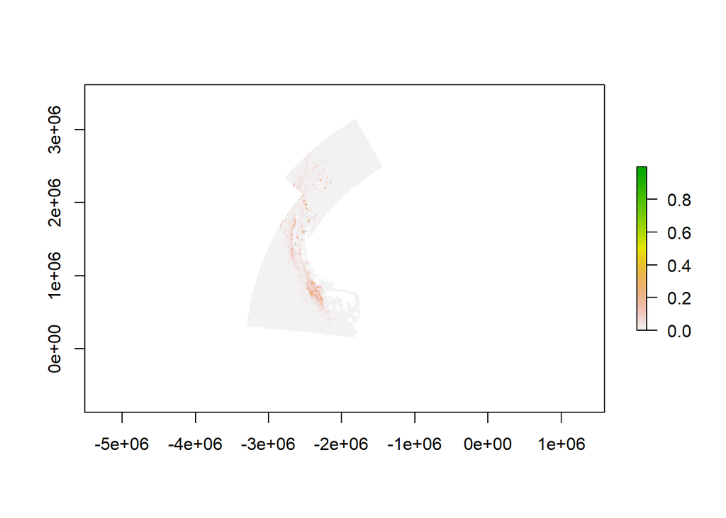

```r
ym3<-y3/77.001

plot(ym3)
```

```r
writeRaster(ym3,"C:/D1MPA_2024_Harmony/D1MPA_Harmonized/Predators_rescaled_area_usage/Seal_Elephant_JAS.tif", overwrite=TRUE)

#ond
d4 <- data.frame(x=soes.q4$x,y=soes.q4$y, tms=soes.q4$date, id=soes.q4$idy)
tr4 <- trip(d4)
tg4 <- rasterize(tr4, mask, field = "tms") # in seconds

y4<-(cover(tg4,mask)/(3600)/24)+mask

max(y4)
```

```
## class      : RasterLayer
## dimensions : 448, 377, 168896  (nrow, ncol, ncell)
## resolution : 10000, 10000  (x, y)
## extent     : -3844389, -74389.02, -867299.4, 3612701  (xmin, xmax, ymin, ymax)
## crs        : +proj=laea +lat_0=-90 +lon_0=0 +x_0=0 +y_0=0 +datum=WGS84 +units=m +no_defs
## source     : memory
## names      : layer
## values     : 0, 367.0088  (min, max)
```

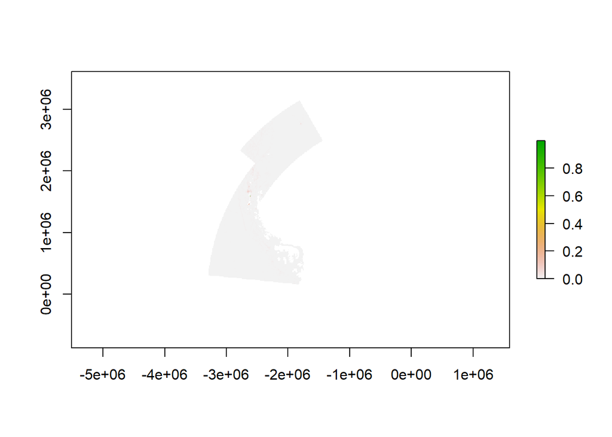

```r
ym4<-y4/367.01

plot(ym4)
```

[figure not shown]

```r
writeRaster(ym4,"C:/D1MPA_2024_Harmony/D1MPA_Harmonized/Predators_rescaled_area_usage/Seal_Elephant_OND.tif", overwrite=TRUE)


###-------Penguins------------

pengm<-read.csv("C:/D1MPA_2024_Harmony/D1MPA_Harmonized/Processed_Tracking_Data/penguins.csv")

pengm$timestamp<-as.POSIXct(strptime(pengm$timestamp,
                                     format="%Y-%m-%d %H:%M:%S", tz="GMT"))
pengm$month<-month(pengm$timestamp)
pengm$id<-paste(pengm$Spp,pengm$id,pengm$month)

#pengm<-subset(pengm,month<9)

pengm2<-plyr::ddply(pengm, c("id"), summarise,
                    N=length(lon))

pengms<-merge(pengm,pengm2,by="id")

pengms<-subset(pengms,N.y>5)

adp<-subset(pengms,Spp=="ADPE")
chp<-subset(pengms,Spp=="CHPE")
gep<-subset(pengms,Spp=="GEPE")

adp<-subset(adp,lon>(-75))

gep<-subset(gep,lon<(-50) & lon>(-67))
gep<-subset(gep,lat<(-61.5))

adsp<-SpatialPointsDataFrame(adp[6:7],adp,proj4string = EPSG4326)
chsp<-SpatialPointsDataFrame(chp[6:7],chp,proj4string = EPSG4326)
gesp<-SpatialPointsDataFrame(gep[6:7],gep,proj4string = EPSG4326)

adspW<-sp::spTransform(adsp,CRS("+proj=laea +lat_0=-90 +lon_0=0 +x_0=0 +y_0=0 +datum=WGS84 +units=m +no_defs"))
chspW<-sp::spTransform(chsp,CRS("+proj=laea +lat_0=-90 +lon_0=0 +x_0=0 +y_0=0 +datum=WGS84 +units=m +no_defs"))
gespW<-sp::spTransform(gesp,CRS("+proj=laea +lat_0=-90 +lon_0=0 +x_0=0 +y_0=0 +datum=WGS84 +units=m +no_defs"))

plot(adspW)
```

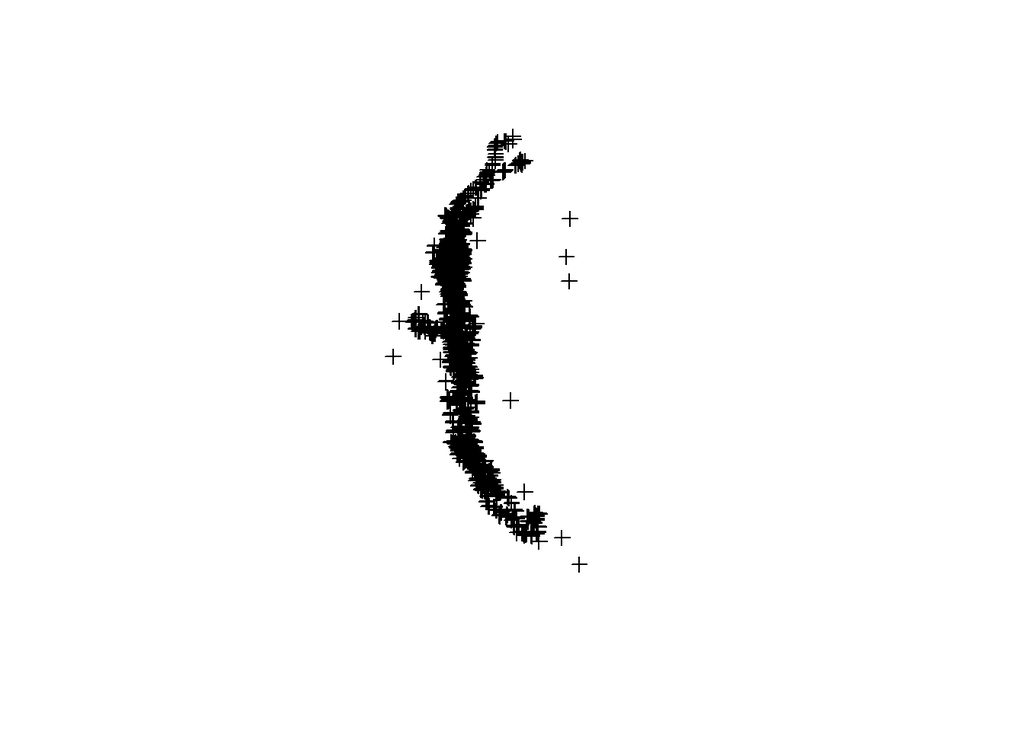

```r
plot(chspW)
```

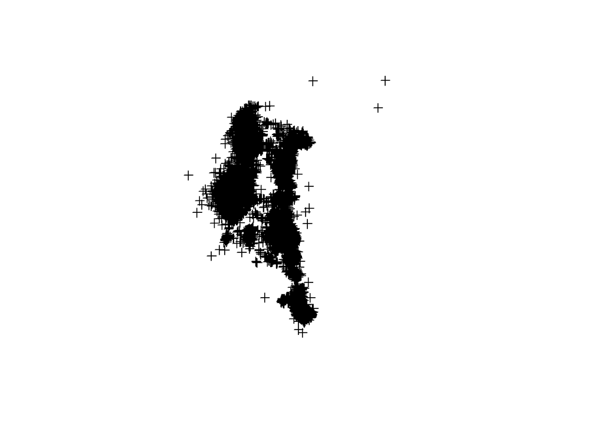

```r
plot(gespW)
```

```r
### --------gentoo penguin----------------

gepW<-raster::intersect(gespW,D1)

geps<-data.frame(gepW)

head(geps)
```

```
##         id X  Spp           timestamp Col       lon       lat N.x month N.y
## 1 GEPE 1 1 1 GEPE 2009-01-12 13:39:00  CS -60.57778 -62.43500  25     1  25
## 2 GEPE 1 1 2 GEPE 2009-01-12 15:22:00  CS -60.85556 -62.45889  25     1  25
## 3 GEPE 1 1 3 GEPE 2009-01-12 17:03:00  CS -60.83611 -62.46139  25     1  25
## 4 GEPE 1 1 4 GEPE 2009-01-12 17:06:00  CS -60.86111 -62.46139  25     1  25
## 5 GEPE 1 1 5 GEPE 2009-01-12 17:49:00  CS -60.92500 -62.46056  25     1  25
## 6 GEPE 1 1 6 GEPE 2009-01-12 18:45:00  CS -60.81111 -62.45889  25     1  25
##   OBJECTID Index Name                                 Location     Km2
## 1        1     0    1 NEW Western Peninsula - South Scotia Arc 2372682
## 2        1     0    1 NEW Western Peninsula - South Scotia Arc 2372682
## 3        1     0    1 NEW Western Peninsula - South Scotia Arc 2372682
## 4        1     0    1 NEW Western Peninsula - South Scotia Arc 2372682
## 5        1     0    1 NEW Western Peninsula - South Scotia Arc 2372682
## 6        1     0    1 NEW Western Peninsula - South Scotia Arc 2372682
##   Shape_Leng   Shape_Area        x       y optional
## 1   26975653 2.375862e+12 -2654004 1496811     TRUE
## 2   26975653 2.375862e+12 -2658971 1482667     TRUE
## 3   26975653 2.375862e+12 -2658232 1483438     TRUE
## 4   26975653 2.375862e+12 -2658879 1482278     TRUE
## 5   26975653 2.375862e+12 -2660609 1479356     TRUE
## 6   26975653 2.375862e+12 -2657821 1484729     TRUE
```

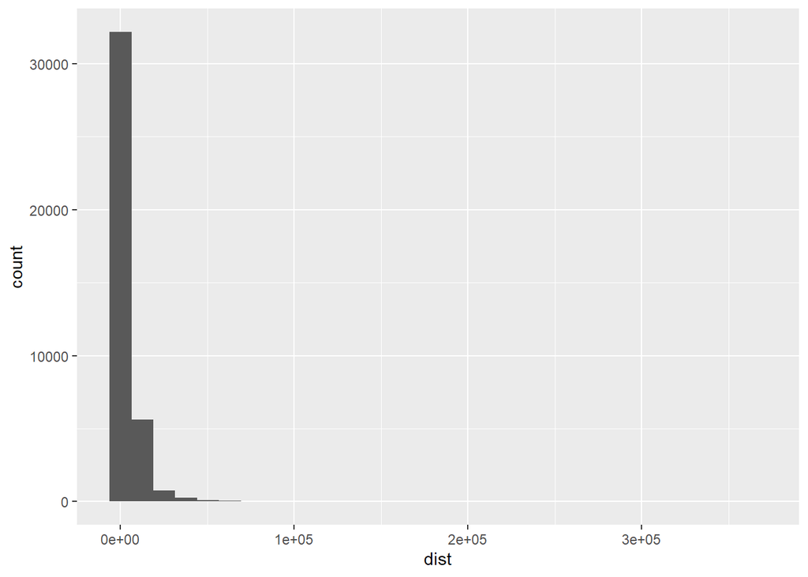

```r
geps<- geps[!duplicated(geps[, c("timestamp","id")]), ]

gep.lt<-as.ltraj(xy=geps[18:19],date=geps$timestamp,id=geps$id,proj4string = EPSG6932)

gep.ld<-ld(gep.lt)

ggplot(gep.ld,aes(dist))+geom_histogram()
```

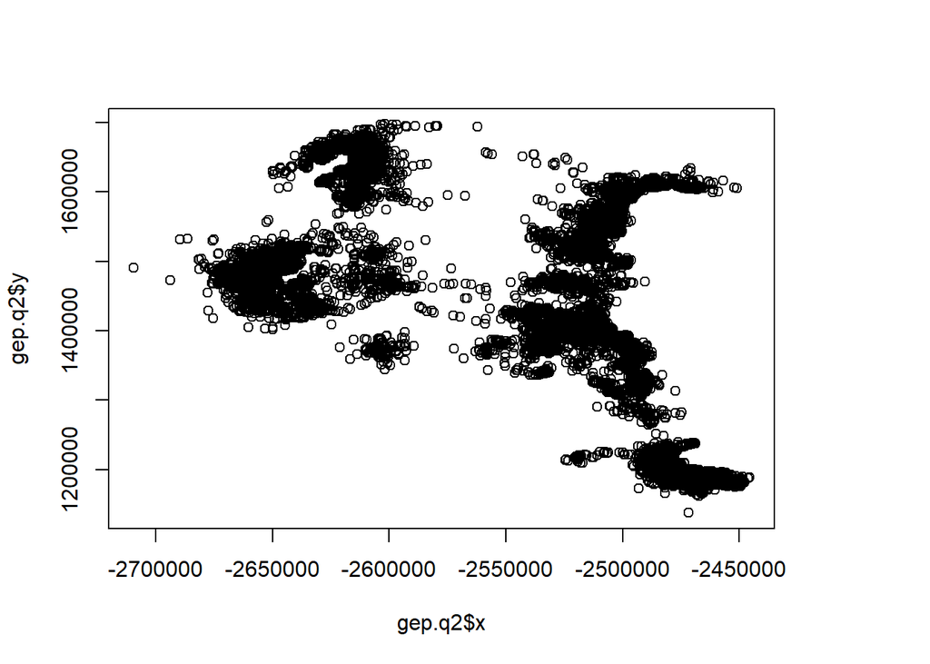

```r
gep.ld2<-subset(gep.ld,dist<50000) #eliminate positions based on consecutive points distance

gep.ld2$year<-year(gep.ld2$date)

gep.ld2$quarter<-quarter(gep.ld2$date)
gep.q1<-subset(gep.ld2,quarter=="1")
gep.q2<-subset(gep.ld2,quarter=="2")
gep.q3<-subset(gep.ld2,quarter=="3")
gep.q4<-subset(gep.ld2,quarter=="4")

plot(gep.q2$x,gep.q2$y)
```

```r
# amj

d <- data.frame(x=gep.q2$x,y=gep.q2$y, tms=gep.q2$date, id=gep.q2$id)
tr <- trip(d,correct_all = T)
tg <- rasterize(tr, mask, field = "tms") # in seconds

y<-(cover(tg,mask)/(3600)/24)+mask

max(y)
```

```
## class      : RasterLayer
## dimensions : 448, 377, 168896  (nrow, ncol, ncell)
## resolution : 10000, 10000  (x, y)
## extent     : -3844389, -74389.02, -867299.4, 3612701  (xmin, xmax, ymin, ymax)
## crs        : +proj=laea +lat_0=-90 +lon_0=0 +x_0=0 +y_0=0 +datum=WGS84 +units=m +no_defs
## source     : memory
## names      : layer
## values     : 0, 8.710799  (min, max)
```

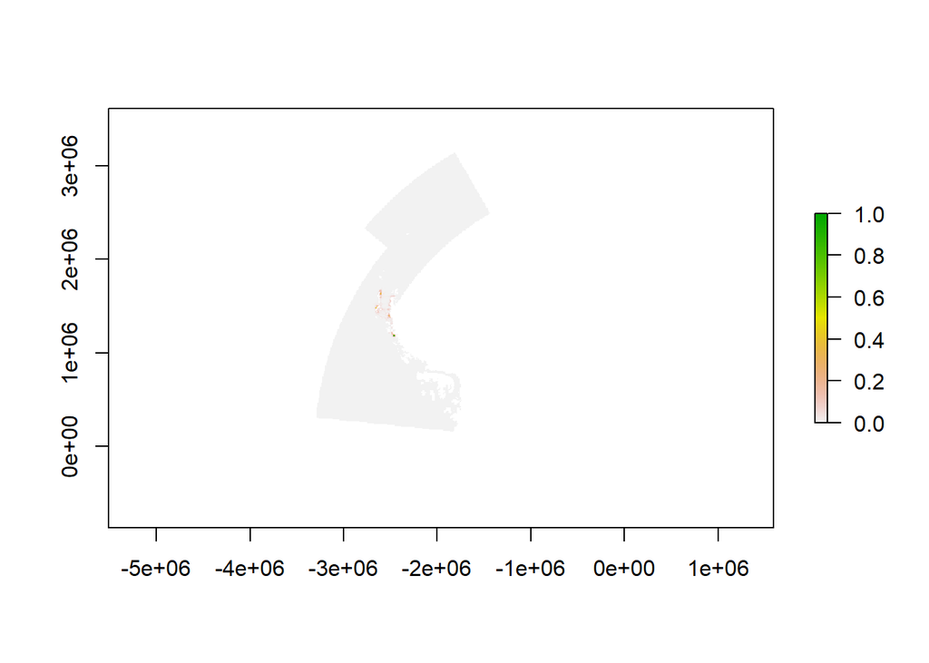

```r
ym<-y/8.71

plot(ym)
```

```r
writeRaster(ym,"C:/D1MPA_2024_Harmony/D1MPA_Harmonized/Predators_rescaled_area_usage/Penguin_Gentoo_AMJ.tif", overwrite=TRUE)

# jas

d3 <- data.frame(x=gep.q3$x,y=gep.q3$y, tms=gep.q3$date, id=gep.q3$id)
tr3 <- trip(d3,correct_all = T)

tg3 <- rasterize(tr3, mask, field = "tms") # in seconds

y3<-(cover(tg3,mask)/(3600)/24)+mask

max(y3)
```

```
## class      : RasterLayer
## dimensions : 448, 377, 168896  (nrow, ncol, ncell)
## resolution : 10000, 10000  (x, y)
## extent     : -3844389, -74389.02, -867299.4, 3612701  (xmin, xmax, ymin, ymax)
## crs        : +proj=laea +lat_0=-90 +lon_0=0 +x_0=0 +y_0=0 +datum=WGS84 +units=m +no_defs
## source     : memory
## names      : layer
## values     : 0, 1.137257  (min, max)
```

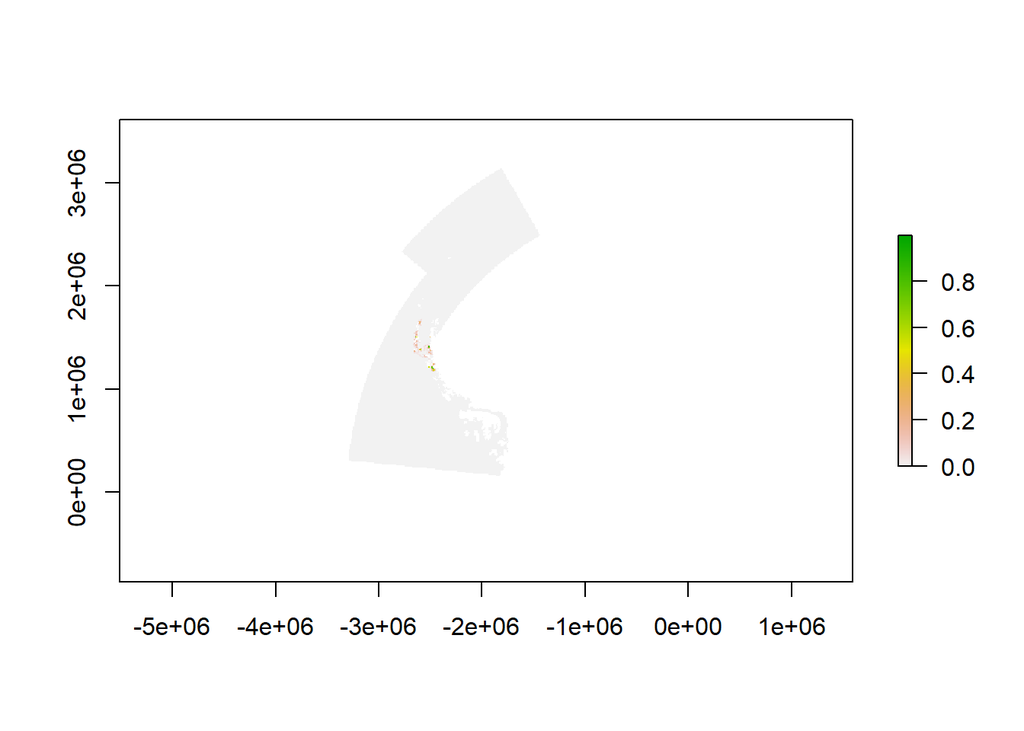

```r
ym3<-y3/1.14

plot(ym3)
```

```r
writeRaster(ym3,"C:/D1MPA_2024_Harmony/D1MPA_Harmonized/Predators_rescaled_area_usage/Penguin_Gentoo_JAS.tif", overwrite=TRUE)

### -----chinstrap-------

summary(as.factor(chp$Col))
```

```
##  COPA    CS
##  2452 14907
```

```r
chspW<-raster::intersect(chspW,D1)

chps<-data.frame(chspW)

chps<- chps[!duplicated(chps[, c("timestamp","id")]), ]

head(chps)
```

```
##           id   X  Spp           timestamp Col       lon       lat N.x month N.y
## 1 CHPE 106 1 294 CHPE 2009-01-04 15:09:00  CS -60.89167 -62.46417  19     1  19
## 2 CHPE 106 1 295 CHPE 2009-01-04 21:06:00  CS -61.11944 -62.27056  19     1  19
## 3 CHPE 106 1 296 CHPE 2009-01-04 21:12:00  CS -61.01667 -62.27583  19     1  19
## 4 CHPE 106 1 297 CHPE 2009-01-04 22:53:00  CS -61.21389 -62.21083  19     1  19
## 5 CHPE 106 1 298 CHPE 2009-01-05 00:34:00  CS -61.28611 -62.20556  19     1  19
## 6 CHPE 106 1 299 CHPE 2009-01-05 01:01:00  CS -60.93611 -62.27528  19     1  19
##   OBJECTID Index Name                                 Location     Km2
## 1        1     0    1 NEW Western Peninsula - South Scotia Arc 2372682
## 2        1     0    1 NEW Western Peninsula - South Scotia Arc 2372682
## 3        1     0    1 NEW Western Peninsula - South Scotia Arc 2372682
## 4        1     0    1 NEW Western Peninsula - South Scotia Arc 2372682
## 5        1     0    1 NEW Western Peninsula - South Scotia Arc 2372682
## 6        1     0    1 NEW Western Peninsula - South Scotia Arc 2372682
##   Shape_Leng   Shape_Area        x       y optional
## 1   26975653 2.375862e+12 -2659406 1480713     TRUE
## 2   26975653 2.375862e+12 -2683620 1480250     TRUE
## 3   26975653 2.375862e+12 -2680461 1484784     TRUE
## 4   26975653 2.375862e+12 -2691719 1478936     TRUE
## 5   26975653 2.375862e+12 -2694082 1475816     TRUE
## 6   26975653 2.375862e+12 -2678423 1488581     TRUE
```

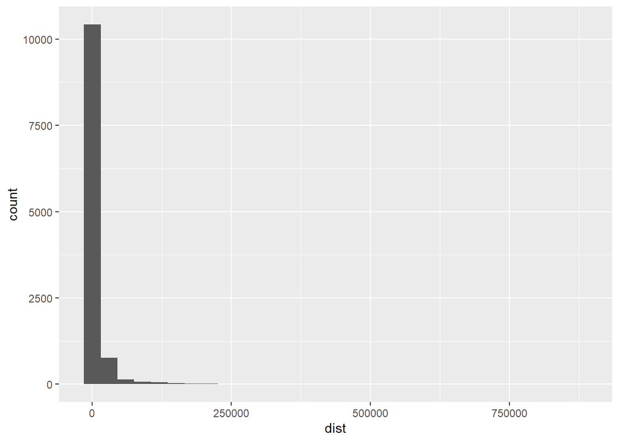

```r
chp.lt<-as.ltraj(xy=chps[18:19],date=chps$timestamp,id=chps$id,proj4string = EPSG6932)

chp.ld<-ld(chp.lt)

ggplot(chp.ld,aes(dist))+geom_histogram()
```

```r
chp.ld2<-subset(chp.ld,dist<50000) #eliminate positions based on consecutive points distance

chp.ld2$quarter<-quarter(chp.ld2$date)
chp.q1<-subset(chp.ld2,quarter=="1")
chp.q2<-subset(chp.ld2,quarter=="2")
chp.q3<-subset(chp.ld2,quarter=="3")
chp.q4<-subset(chp.ld2,quarter=="4")

# amj

d <- data.frame(x=chp.q2$x,y=chp.q2$y, tms=chp.q2$date, id=chp.q2$id)

tr <- trip(d,correct_all = T)

tg <- rasterize(tr, mask, field = "tms") # in seconds

y<-(cover(tg,mask)/(3600)/24)+mask

max(y)
```

```
## class      : RasterLayer
## dimensions : 448, 377, 168896  (nrow, ncol, ncell)
## resolution : 10000, 10000  (x, y)
## extent     : -3844389, -74389.02, -867299.4, 3612701  (xmin, xmax, ymin, ymax)
## crs        : +proj=laea +lat_0=-90 +lon_0=0 +x_0=0 +y_0=0 +datum=WGS84 +units=m +no_defs
## source     : memory
## names      : layer
## values     : 0, 1.152593  (min, max)
```

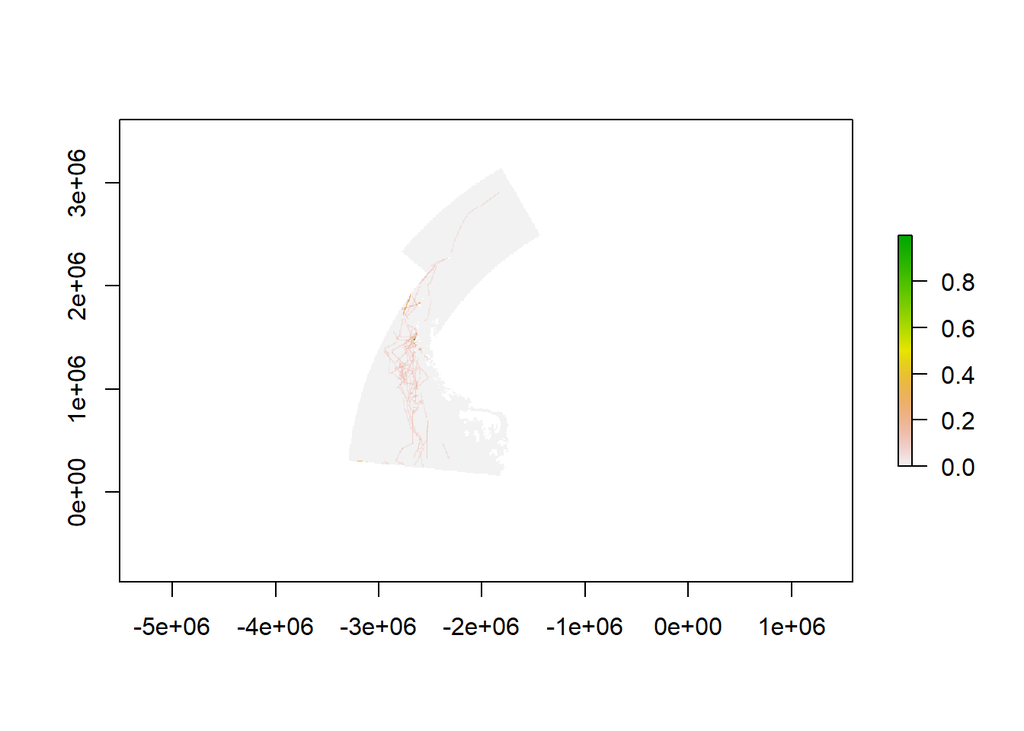

```r
ym<-y/1.153

plot(ym)
```

```r
writeRaster(ym,"C:/D1MPA_2024_Harmony/D1MPA_Harmonized/Predators_rescaled_area_usage/Penguin_Chinstrap_AMJ.tif", overwrite=TRUE)

# jas

d <- data.frame(x=chp.q3$x,y=chp.q3$y, tms=chp.q3$date, id=chp.q3$id)
tr <- trip(d,correct_all = T)

tg <- rasterize(tr, mask, field = "tms") # in seconds

y<-(cover(tg,mask)/(3600)/24)+mask

max(y)
```

```
## class      : RasterLayer
## dimensions : 448, 377, 168896  (nrow, ncol, ncell)
## resolution : 10000, 10000  (x, y)
## extent     : -3844389, -74389.02, -867299.4, 3612701  (xmin, xmax, ymin, ymax)
## crs        : +proj=laea +lat_0=-90 +lon_0=0 +x_0=0 +y_0=0 +datum=WGS84 +units=m +no_defs
## source     : memory
## names      : layer
## values     : 0, 0.1413542  (min, max)
```

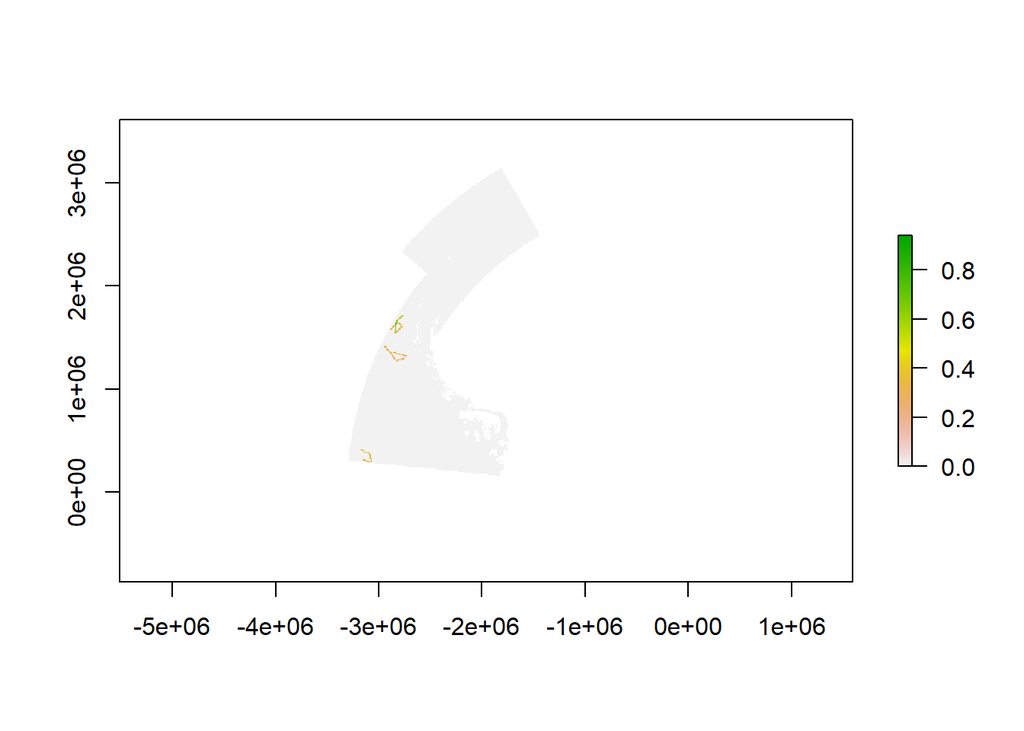

```r
ym<-y/0.15

plot(ym)
```

```r
writeRaster(ym,"C:/D1MPA_2024_Harmony/D1MPA_Harmonized/Predators_rescaled_area_usage/Penguin_Chinstrap_JAS.tif", overwrite=TRUE)

##----------adelie penguin--------------

summary(as.factor(adp$Col))
```

```
##  COPA   SOI
##  6461 19002
```

```r
adspW<-raster::intersect(adspW,D1)

adps<-data.frame(adspW)


adps<- adps[!duplicated(adps[, c("timestamp","id")]), ]

head(adps)
```

```
##           id   X  Spp           timestamp  Col     lon     lat N.x month N.y
## 1 ADPE 100 1  89 ADPE 2013-01-01 12:41:00 COPA -58.412 -62.183  32     1  29
## 2 ADPE 100 1  93 ADPE 2013-01-02 20:38:00 COPA -58.439 -62.125  32     1  29
## 3 ADPE 100 1  94 ADPE 2013-01-03 06:30:00 COPA -58.457 -62.094  32     1  29
## 4 ADPE 100 1  95 ADPE 2013-01-03 08:10:00 COPA -58.420 -62.143  32     1  29
## 5 ADPE 100 1 101 ADPE 2013-01-05 12:56:00 COPA -58.431 -62.116  32     1  29
## 6 ADPE 100 1 102 ADPE 2013-01-06 00:59:00 COPA -58.600 -62.160  32     1  29
##   OBJECTID Index Name                                 Location     Km2
## 1        1     0    1 NEW Western Peninsula - South Scotia Arc 2372682
## 2        1     0    1 NEW Western Peninsula - South Scotia Arc 2372682
## 3        1     0    1 NEW Western Peninsula - South Scotia Arc 2372682
## 4        1     0    1 NEW Western Peninsula - South Scotia Arc 2372682
## 5        1     0    1 NEW Western Peninsula - South Scotia Arc 2372682
## 6        1     0    1 NEW Western Peninsula - South Scotia Arc 2372682
##   Shape_Leng   Shape_Area        x       y optional
## 1   26975653 2.375862e+12 -2618772 1610323     TRUE
## 2   26975653 2.375862e+12 -2624877 1612373     TRUE
## 3   26975653 2.375862e+12 -2628241 1613303     TRUE
## 4   26975653 2.375862e+12 -2622683 1612224     TRUE
## 5   26975653 2.375862e+12 -2625481 1613249     TRUE
## 6   26975653 2.375862e+12 -2626166 1603018     TRUE
```

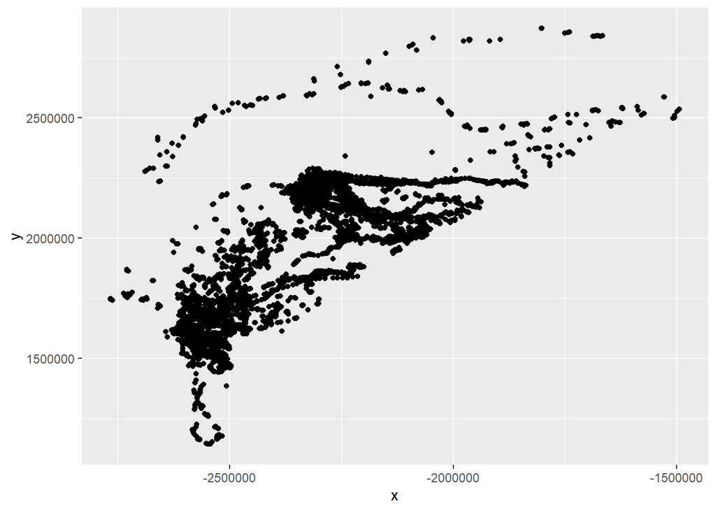

```r
adp.lt<-as.ltraj(xy=adps[18:19],date=adps$timestamp,id=adps$id,proj4string = EPSG6932)

adp.ld<-ld(adp.lt)

ggplot(adp.ld,aes(x,y))+geom_point()
```

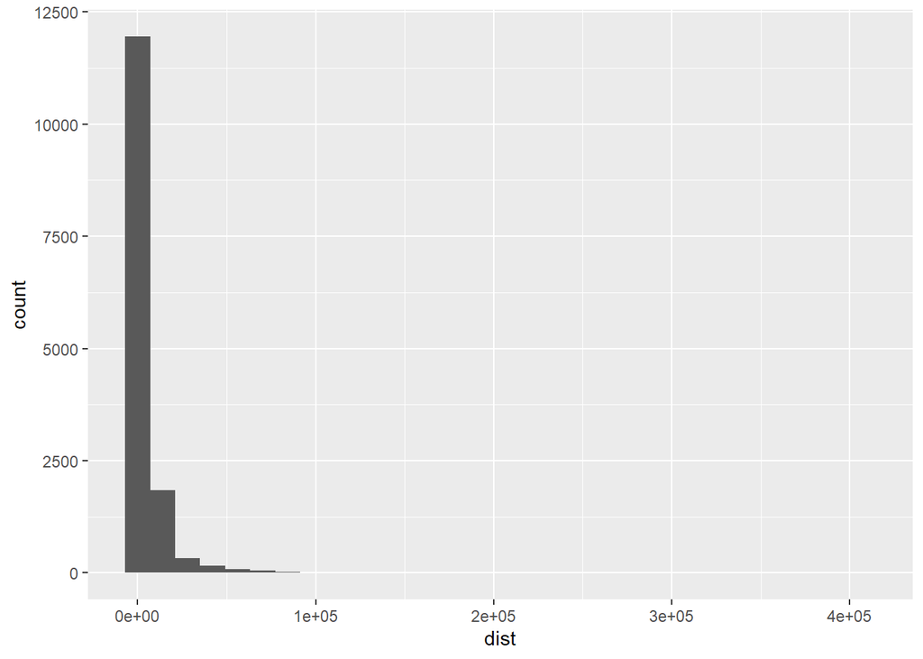

```r
ggplot(adp.ld,aes(dist))+geom_histogram()
```

```r
adp.ld2<-subset(adp.ld,dist<50000) #eliminate positions based on consecutive points distance

adp.ld2$month<-month(adp.ld2$date)

adspM<-subset(adp.ld2,month=="2"|month=="3"|month=="4"|month=="1")


d <- data.frame(x=adspM$x,y=adspM$y, tms=adspM$date, id=adspM$id)
tr <- trip(d,correct_all = T)
tg <- rasterize(tr, mask, field = "tms") # in seconds

y<-(cover(tg,mask)/(3600)/24)+mask

max(y)
```

```
## class      : RasterLayer
## dimensions : 448, 377, 168896  (nrow, ncol, ncell)
## resolution : 10000, 10000  (x, y)
## extent     : -3844389, -74389.02, -867299.4, 3612701  (xmin, xmax, ymin, ymax)
## crs        : +proj=laea +lat_0=-90 +lon_0=0 +x_0=0 +y_0=0 +datum=WGS84 +units=m +no_defs
## source     : memory
## names      : layer
## values     : 0, 10.06916  (min, max)
```

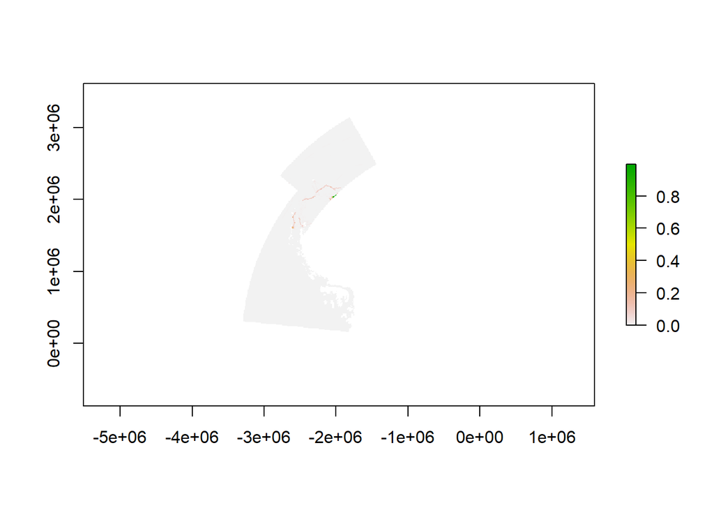

```r
ym<-y/10.1

plot(ym)
```

```r
writeRaster(ym,"C:/D1MPA_2024_Harmony/D1MPA_Harmonized/Predators_rescaled_area_usage/Penguin_Adelie_Mig.tif", overwrite=TRUE)
```

Now join all the predators layers to generate a grid file that represents the number of layers, which is one of the criteria used to redefine GPZ.After generating those files, vertices for the new boundaries were drawn in ArcMap, and a .csv file was generated.

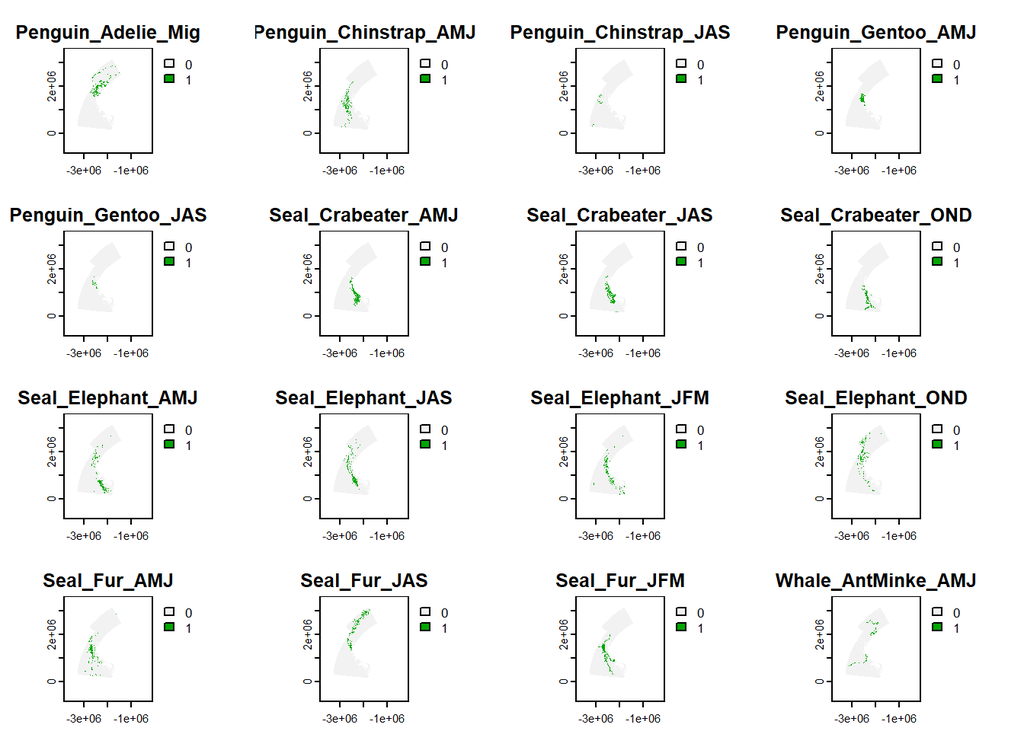

```r
###------------- rescale data to binary ----------------

# load files

# Set the directory where TIF files are located
tif_directory <- "C:/D1MPA_2024_Harmony/D1MPA_Harmonized/Predators_rescaled_area_usage/"

# List all TIF files in the directory
tif_files <- list.files(tif_directory, pattern = ".tif$", full.names = T)

# Load all TIF files into a raster stack
raster_stack <- terra::rast(tif_files)

# Define the number of intervals
num_intervals <- 2


for (i in 1:nlyr(raster_stack)) {
  # Extract the ith layer
  raster_layer <- raster_stack[[i]]

  # Calculate the 0.05 quantile
  quantile_005 <- quantile(values(raster_layer), probs = 0.95,na.rm=T)

  # Reclassify the raster layer
  reclassified_layer <- terra::ifel(raster_layer > quantile_005, 1, 0)

  # Replace the original layer with the reclassified layer in the raster stack
  raster_stack[[i]] <- reclassified_layer
}


# Plot the reclassified raster stack
plot(raster_stack)
```

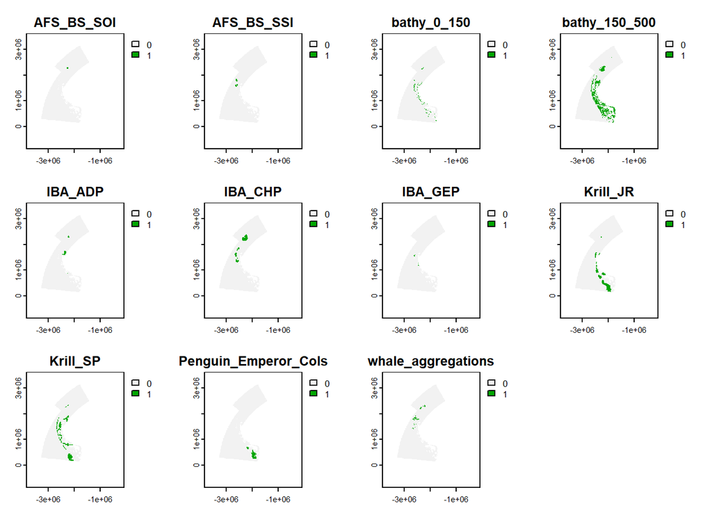

```r
# load additional binary files

# Set the directory where TIF files are located
tif_directory2 <- "C:/D1MPA_2024_Harmony/D1MPA_Harmonized/Non-tracking_layers/"

# List all TIF files in the directory
tif_files2 <- list.files(tif_directory2, pattern = ".tif$", full.names = T)


# Load all TIF files into a raster stack
raster_stack2 <- terra::rast(tif_files2)
plot(raster_stack2)
```

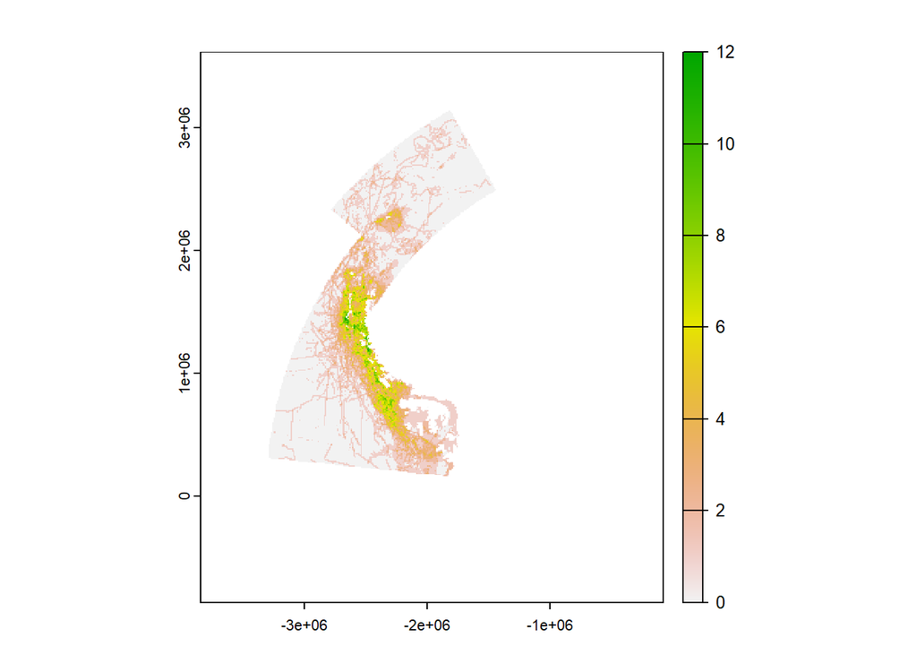

```r
#stack both stacks together
rasters<-c(raster_stack,raster_stack2)

rsum<-sum(rasters) # sum all stacks

plot(rsum)
```